# TWD PD5

Piotr Pasza Storozenko

20 listopada 2018

## Przeprowadzony eksperyment

Przeprowadzony został następujący eksperyment przy pomocy [formularzy googla](https://goo.gl/forms/8gyFRLWfUkU1rrw13).

Najpierw uczestnikom przedstawiona została informacja:

> Formularz jest pracą domową na przedmiot Techniki Wizualizacji danych.

> W kolejnych sekcjach zostaniesz zapytany o odpowiedzi na 2x4 pytania, w sumie 8. Pytania są proste :)

> W odpowiedzi proszę napisać tylko jedną liczbę, w formacie dziesiętnym np. 3.14 albo 0.314.

Następnie został pokazany poniższy wykres:

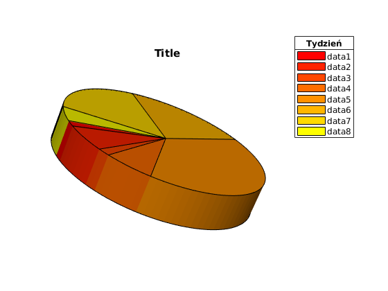

Wykres nr 1 przedstawiający ilość sprzedanych cukierków w zależności od tygodnia.

Oraz zostali oni zapytani ,,Jaki jest stosunek sprzedanych cukierków w […]?’’

1. tygodniu 1 do tygodnia 5
2. tygodniu 5 do tygodnia 6
3. tygodniu 6 do tygodnia 7
4. tygodniu 2 do tygodnia 4

Po odpowiedzeniu na te pytania, uczestnikom przedstawiony został kolejny wykres:

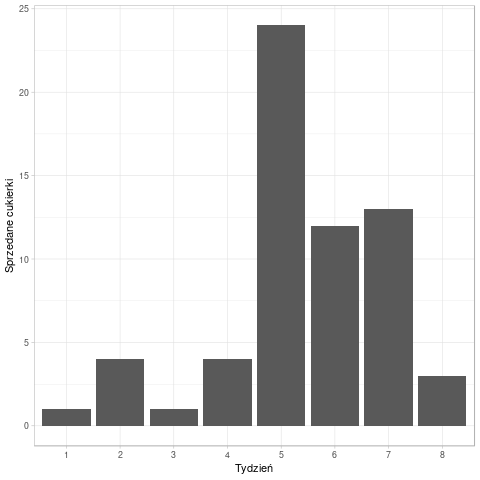

Wykres nr 2 przedstawiający ilość sprzedanych cukierków w zależności od tygodnia.

I zostali oni zapytani o te same pytania.

## Cel eksperymentu

Celem eksperymentu było dowiedzenie się ile informacji uczestnicy są w stanie wynieść z wykresu 1 oraz sprawdzenie jak uczestnicy poradzą sobie z interpretacją pytań.

## Rezultaty

Eksperyment przeprowadzono na 28 osobach.

### Poprawność liczbowa odpowiedzi

Na czerwono zostały przedstawione wyniki uzyskane dla pierwszego wykresu. Na niebiesko dla drugiego wykresu. Pionową, czarną prostą zaznaczono wartość poprawną.

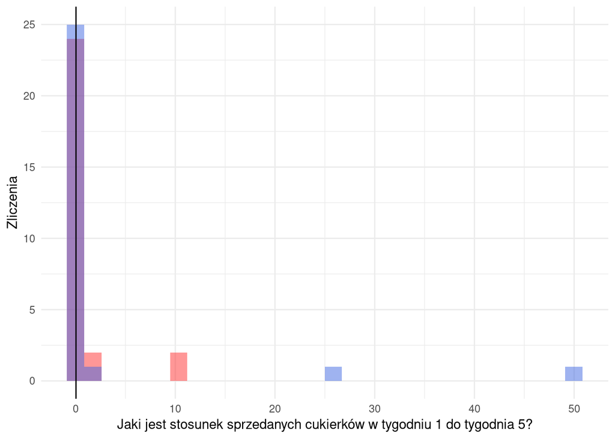

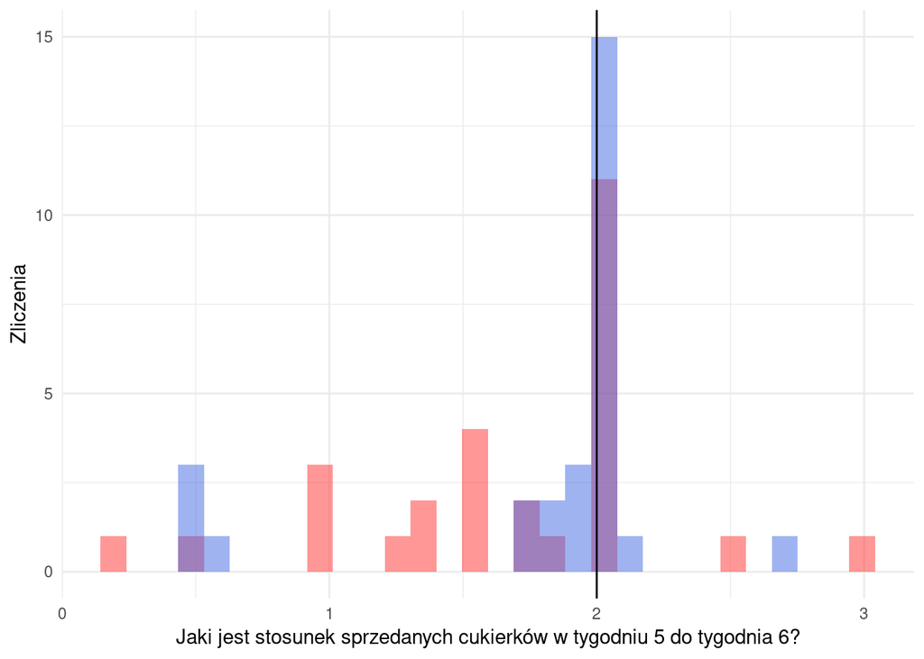

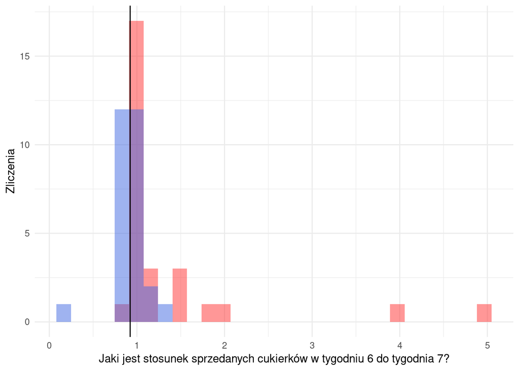

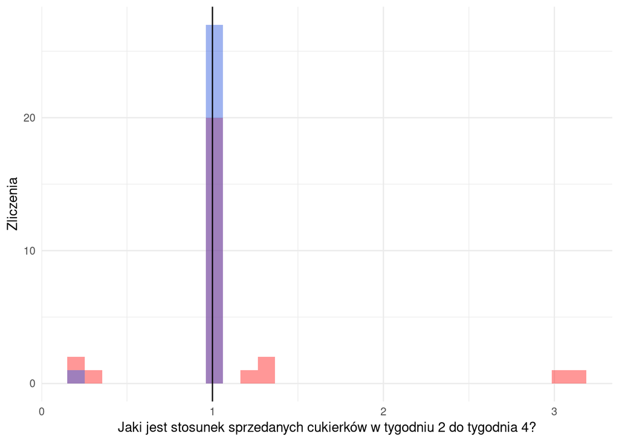

### Poprawność językowa odpowiedzi

Wiele osób udzieliło odpowiedzi w formacie innym niż zostało sprecyzowane we wstępie:

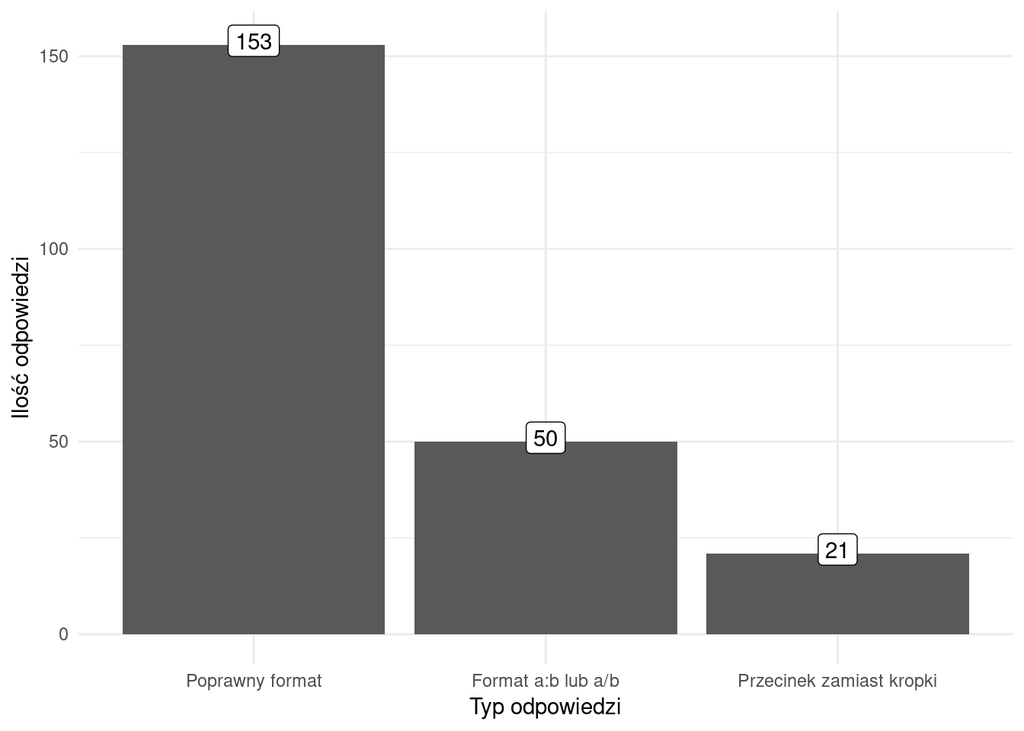

### Wnioski

1. Tak jak się spodziewano, wykresy kołowe 3d zakłamują prezentację danych, co w szczególności widać dla pytania nr 2.
2. W odpowiedziach na pytania nr 1 widać, że niektórzy policzyli stosunek odwrotny.
3. Ostatni wykres pokazuje jak wiele osób wpisało odpowiedź w formacie innym niż oczekiwano. Traktując przypadki z przecinkami jako poprawne, ponad 22% odpowiedzi została udzielona w formacie a:b lub a/b.